# Final Project: Suicide Rate of US States: Why Are They So Different?

### 6.2.3 Thoughts of suicide vs Serious mental illness

Correlation between population with thoughts of suicide and one with serious mental illness by state is strong (r=0.8).

```r
suic_mh<-merge(suicide_tt1, mh_dt, by = "state")

cor(suic_mh$Y18P.x, suic_mh$Y18P.y)
```

```
## [1] 0.7982923
```

[figure not shown]

```r
scatterplot(suic_mh$Y18P.x~suic_mh$Y18P.y,xlab="Thoughts of suicide, %", ylab="Serious Mental Illness, %",
   main="Plot 28. Thoughts of Suicide vs Serious Mental Illness, %")
```

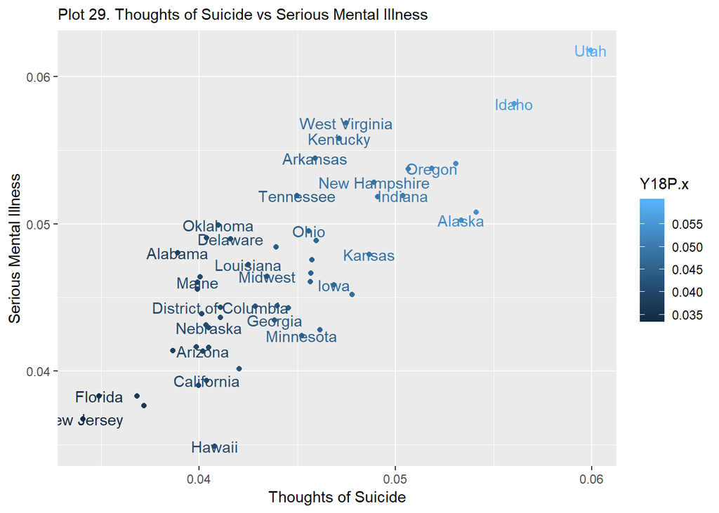

```r
ggplot(suic_mh, aes(Y18P.x,Y18P.y, color = Y18P.x)) + geom_point() + geom_text(aes(label=state), check_overlap = TRUE)+
  labs(subtitle="Plot 29. Thoughts of Suicide vs Serious Mental Illness", x="Thoughts of Suicide", y="Serious Mental Illness")
```

### 6.2.4 Thoughts of suicide vs Substance Abuse

Correlation between population with thoughts of suicide and one with substance abuse disorder is weak/moderate (r=0.3). Interestingly, Utah has low SA problem, but high level of thoughts of suicide, while DC has drug problem but low level of suicide thoughts. Let’s take out these 2 outliers and see if correlation will change. Indeed, correlation improved to r=0.47. Let’s see if correlation is stronger for younger cohort. Actually, it is not (r=0.46). Not what I have expected. I would like to mention that throughout my analysis Utah and DC will be somewhat outliers. Specifically, Utah, a state with low violence, drug and alcohol use, while the rate of suicide is one of the highest in country.

```r
suic_sa<-merge(suicide_tt1, sa_dt, by = "state")

cor(suic_sa$Y18P.x, suic_sa$Y18P.y)
```

```
## [1] 0.2976138
```

[figure not shown]

```r
scatterplot(suic_sa$Y18P.x~suic_sa$Y18P.y,xlab="Thoughts of suicide", ylab="Substance Abuse Illness",
   main="Plot 30. Thoughts of Suicide vs SA Illness")
```

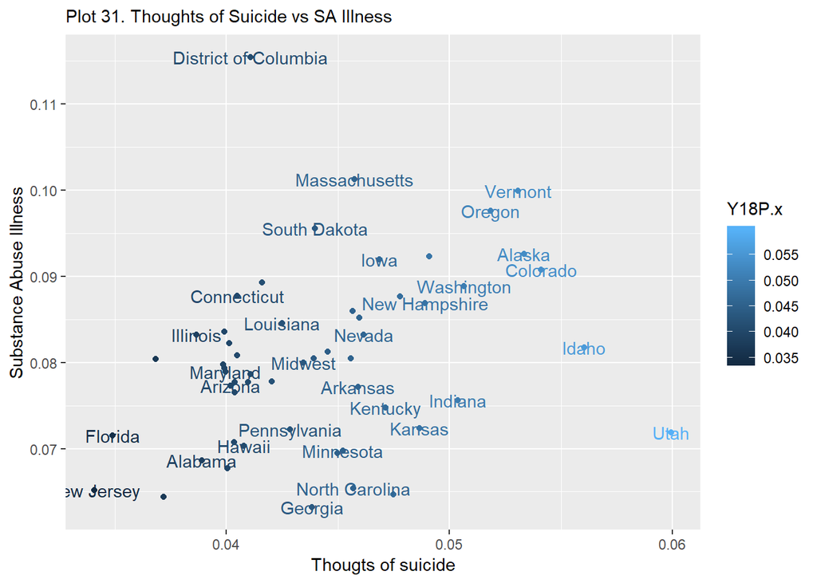

```r
ggplot(suic_sa, aes(Y18P.x,Y18P.y, color = Y18P.x)) + geom_point() + geom_text(aes(label=state), check_overlap = TRUE)+
  labs(subtitle="Plot 31. Thoughts of Suicide vs SA Illness", y="Substance Abuse Illness", x="Thougts of suicide")
```

```r
suic_sa_woo<-filter(suic_sa, !state %in% c('Utah','District of Columbia'))

cor(suic_sa_woo$Y18P.x, suic_sa_woo$Y18P.y)
```

```
## [1] 0.4704185
```

```r
cor(suic_sa_woo$Y18_25.x, suic_sa_woo$Y18_25.y)
```

```
## [1] 0.4625329
```

### 6.2.5 Thoughts of suicide vs Alcohol Abuse

Weak correlation, between alcohol and thoughts of suicide (r=0.27). Strange. Without DC and Utah, correlation goes up to 0.43. Correlation is stronger for younger cohort - 0.53. For younger people, Alaska is an outline. Alaska has moderate alcohol issues and a lot of thoughts of suicide.

```r
suic_alc<-merge(suicide_tt1, alc_dt, by = "state")

cor(suic_alc$Y18P.x, suic_alc$Y18P.y)
```

```
## [1] 0.2730799
```

[figure not shown]

```r
scatterplot(suic_alc$Y18P.x~suic_alc$Y18P.y,xlab="Thoughts of suicide", ylab="Alcohol Disorder",
   main="Plot 32. Thoughts of Suicide vs Alcohol Disorder")
```

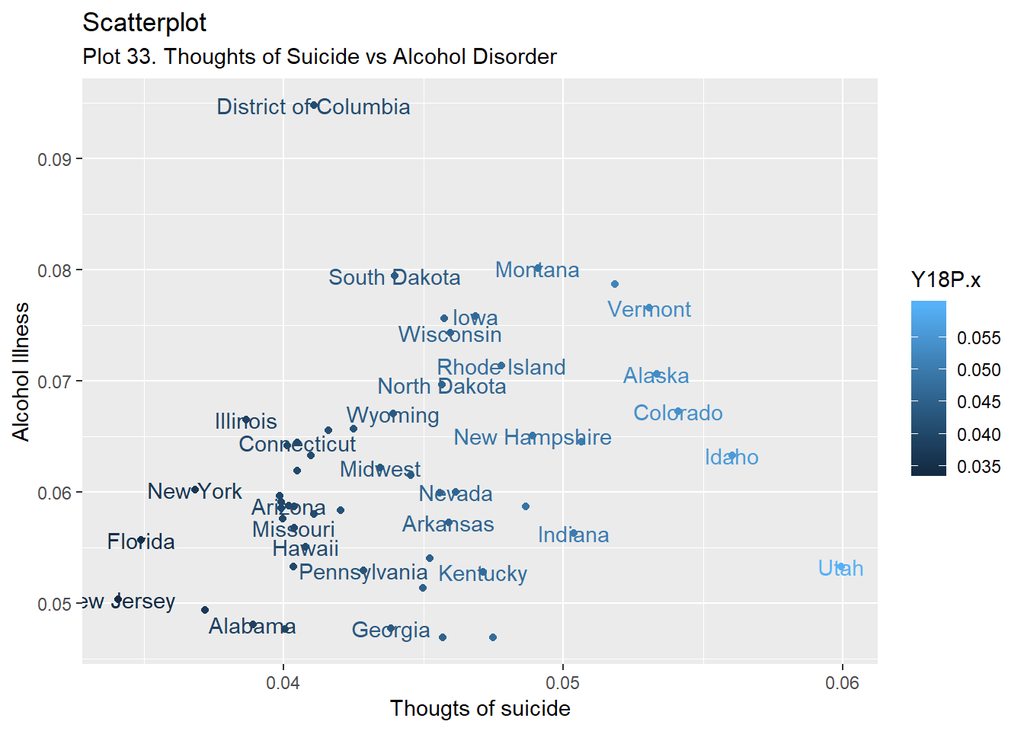

```r
ggplot(suic_alc, aes(Y18P.x,Y18P.y,color=Y18P.x)) + geom_point() + geom_text(aes(label=state), check_overlap = TRUE)+
  labs(subtitle="Plot 33. Thoughts of Suicide vs Alcohol Disorder", y="Alcohol Illness", x="Thougts of suicide", title="Scatterplot")
```

```r
suic_alc_woo<-filter(suic_alc, !state %in% c('Utah','District of Columbia'))

cor(suic_alc_woo$Y18P.x, suic_alc_woo$Y18P.y)
```

```
## [1] 0.4435853
```

```r
cor(suic_alc_woo$Y18_25.x, suic_alc_woo$Y18_25.y)
```

```
## [1] 0.5315146
```

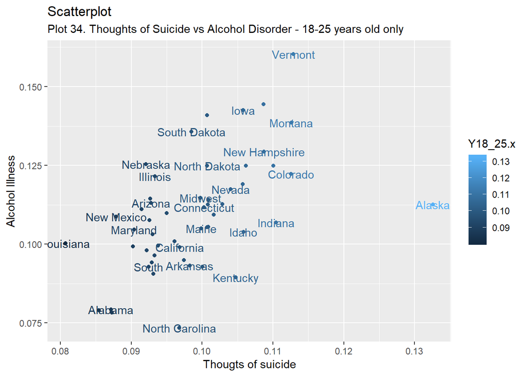

```r
ggplot(suic_alc_woo, aes(Y18_25.x,Y18_25.y, color=Y18_25.x)) + geom_point() + geom_text(aes(label=state), check_overlap = TRUE)+
  labs(subtitle="Plot 34. Thoughts of Suicide vs Alcohol Disorder - 18-25 years old only", y="Alcohol Illness", x="Thougts of suicide", title="Scatterplot")
```

### 6.2.6 Thoughts of suicide vs Painkillers Abuse Disorder

Interestingly, this time neither DC nor Utah are outliers. DC has low painkiller problem and low level of suicide thoughts, while Utah got problems with both. R is moderate 0.46.

```r
suic_pain<-merge(suicide_tt1, pain_dt, by = "state")

cor(suic_pain$Y18P.x, suic_pain$Y18P.y)
```

```
## [1] 0.45627
```

[figure not shown]

```r
scatterplot(suic_pain$Y18P.x~suic_pain$Y18P.y,xlab="Thoughts of suicide", ylab="Painkillers Abuse Disorder",
   main="Plot 35. Thoughts of Suicide vs Painkillers Abuse Disorder, 18+")
```

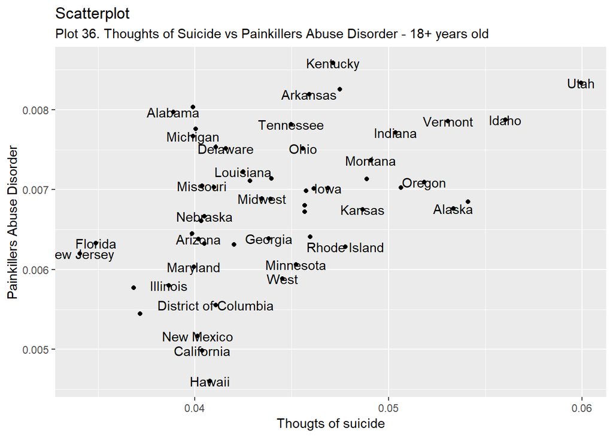

```r
ggplot(suic_pain, aes(Y18P.x,Y18P.y)) + geom_point() + geom_text(aes(label=state), check_overlap = TRUE)+
  labs(subtitle="Plot 36. Thoughts of Suicide vs Painkillers Abuse Disorder - 18+ years old", y="Painkillers Abuse Disorder", x="Thougts of suicide", title="Scatterplot")
```

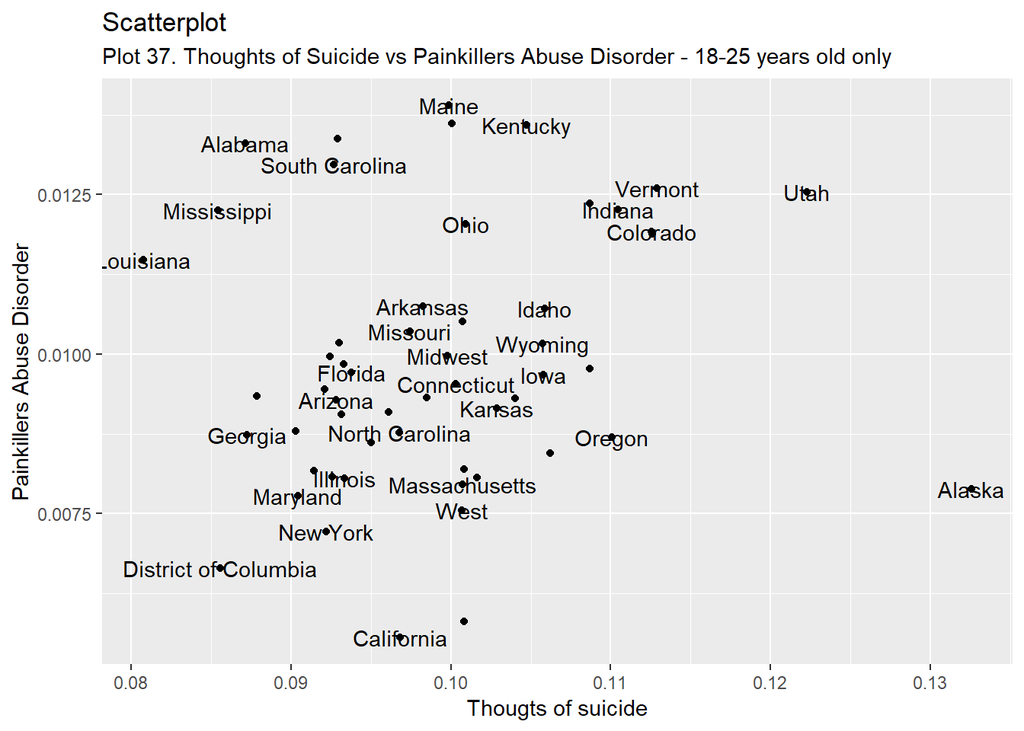

```r
ggplot(suic_pain, aes(Y18_25.x,Y18_25.y)) + geom_point() + geom_text(aes(label=state), check_overlap = TRUE)+
  labs(subtitle="Plot 37. Thoughts of Suicide vs Painkillers Abuse Disorder - 18-25 years old only", y="Painkillers Abuse Disorder", x="Thougts of suicide", title="Scatterplot")
```

```r
cor(suic_pain$Y18_25.x, suic_pain$Y18_25.y)
```

```
## [1] 0.1496557
```

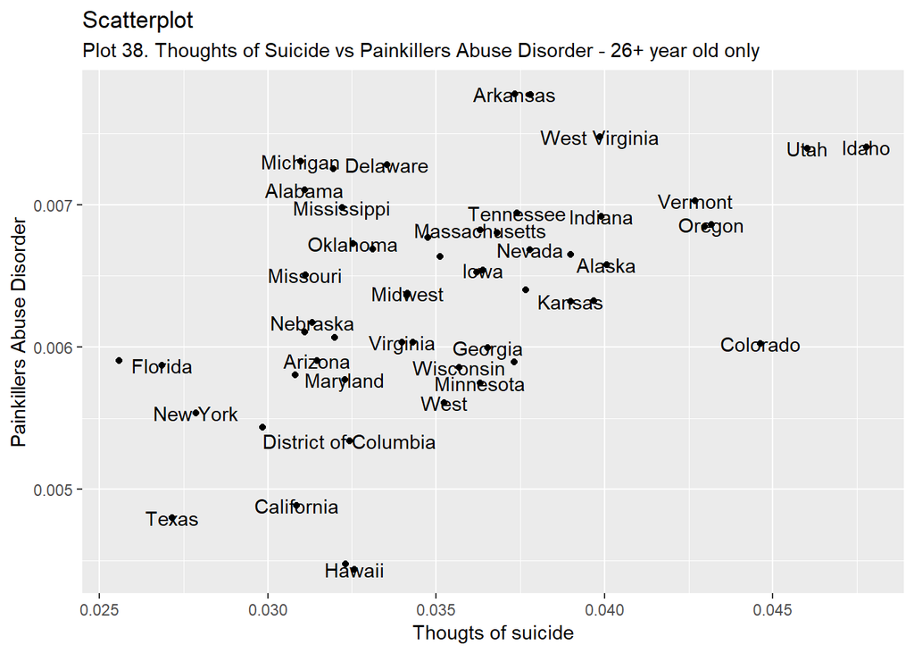

```r
ggplot(suic_pain, aes(Y26P.x,Y26P.y)) + geom_point() + geom_text(aes(label=state), check_overlap = TRUE)+
  labs(subtitle="Plot 38. Thoughts of Suicide vs Painkillers Abuse Disorder - 26+ year old only", y="Painkillers Abuse Disorder", x="Thougts of suicide", title="Scatterplot")
```

```r
cor(suic_pain$Y26P.x, suic_pain$Y26P.y)
```

```
## [1] 0.4922438
```

### 6.2.7 Thoughts of suicide vs Drug Disorder

Similar picture as many other variables, Utah, DC, and Idaho are outliers. DC has low level of suicide thoughts and high level of drug use, while Utah and Idaho are in opposite situation (Utah does have painkiller abuse problem.)

```r
suic_drug<-merge(suicide_tt1, drug_dt, by = "state")

cor(suic_drug$Y18P.x, suic_drug$Y18P.y)
```

```
## [1] 0.314418
```

[figure not shown]

```r
scatterplot(suic_drug$Y18P.x~suic_drug$Y18P.y,xlab="Thoughts of suicide", ylab="Drug Disorder",
   main="Plot 39. Thoughts of Suicide vs Drug Disorder")
```

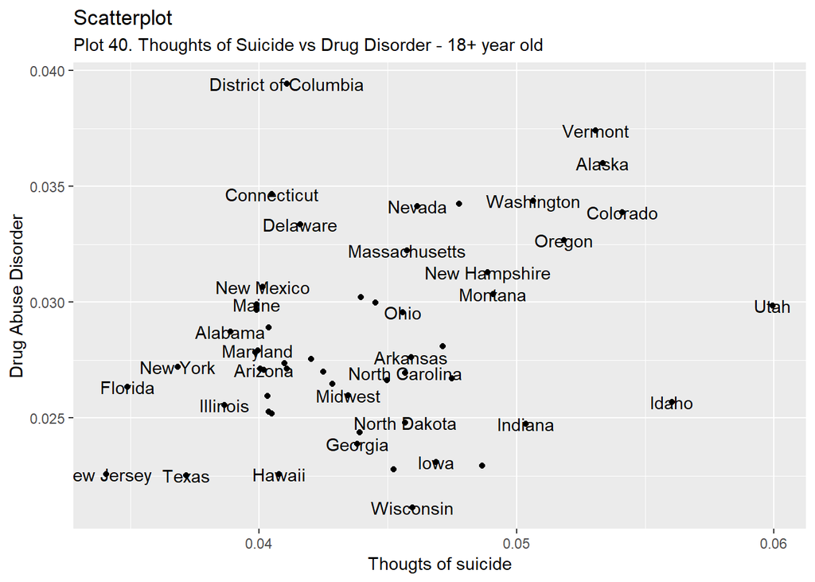

```r
ggplot(suic_drug, aes(Y18P.x,Y18P.y)) + geom_point() + geom_text(aes(label=state), check_overlap = TRUE)+
  labs(subtitle="Plot 40. Thoughts of Suicide vs Drug Disorder - 18+ year old", y="Drug Abuse Disorder", x="Thougts of suicide", title="Scatterplot")
```

### 6.2.8 Thoughts of suicide vs Alcohol Use, Binge Drinking

The first variable that has no correlation at all. Interesting. So, it could be safe to go binge drinking after the project is complete!

```r
suic_binge<-merge(suicide_tt1, alc_usebt, by = "state")

cor(suic_binge$Y18P.x, suic_binge$Y18P.y)
```

```
## [1] -0.06411454
```

[figure not shown]

```r
scatterplot(suic_binge$Y18P.x~suic_binge$Y18P.y,xlab="Thoughts of suicide", ylab="Binge drinking",
   main="Plot 41. Thoughts of Suicide vs Binge drinking")
```

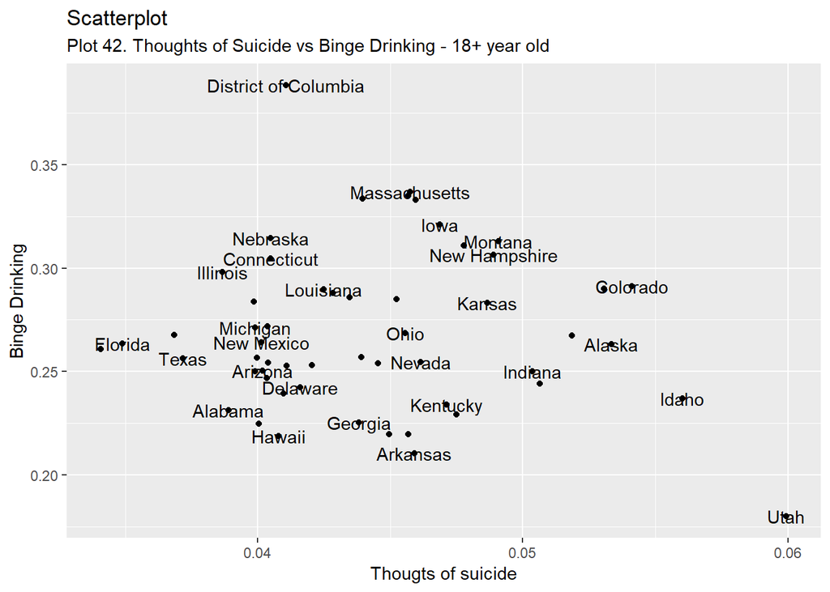

```r
ggplot(suic_binge, aes(Y18P.x,Y18P.y)) + geom_point() + geom_text(aes(label=state), check_overlap = TRUE)+
  labs(subtitle="Plot 42. Thoughts of Suicide vs Binge Drinking - 18+ year old", y="Binge Drinking", x="Thougts of suicide", title="Scatterplot")
```

### 6.2.9 Thoughts of suicide vs Alcohol Consumption

No correlation again. Interesting.

```r
suic_alcd<-merge(suicide_tt1, alc_uset, by = "state")

cor(suic_alcd$Y18P.x, suic_alcd$Y18P.y)
```

```
## [1] -0.02256482
```

[figure not shown]

```r
scatterplot(suic_alcd$Y18P.x~suic_alcd$Y18P.y,xlab="Thoughts of suicide", ylab="Alcohol drinking",
   main="Plot 43. Thoughts of Suicide vs Alcohol drinking")
```

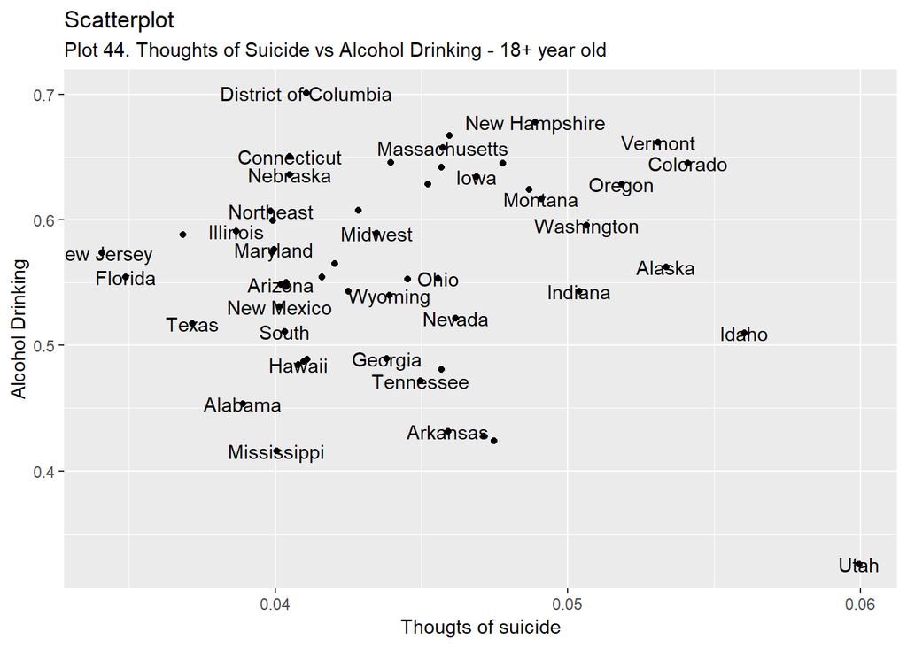

```r
ggplot(suic_alcd, aes(Y18P.x,Y18P.y)) + geom_point() + geom_text(aes(label=state), check_overlap = TRUE)+
  labs(subtitle="Plot 44. Thoughts of Suicide vs Alcohol Drinking - 18+ year old", y="Alcohol Drinking", x="Thougts of suicide", title="Scatterplot")
```

### 6.2.10 Thoughts of suicide vs Heroin Use

Weak correlation.

```r
suic_drugh<-merge(suicide_tt1, drug_useth, by = "state")

cor(suic_drugh$Y18P.x, suic_drugh$Y18P.y)
```

```
## [1] 0.1511048
```

```r
cor(suic_drugh$Y18_25.x, suic_drugh$Y18_25.y)
```

```
## [1] 0.235639
```

[figure not shown]

```r
scatterplot(suic_drugh$Y18P.x~suic_drugh$Y18P.y,xlab="Thoughts of suicide", ylab="Heroin use",
   main="Plot 45. Thoughts of Suicide vs Heroin use")
```

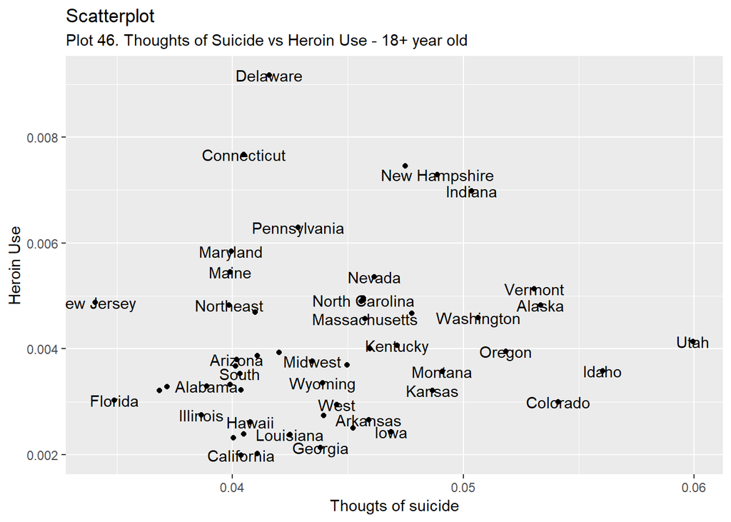

```r
ggplot(suic_drugh, aes(Y18P.x,Y18P.y)) + geom_point() + geom_text(aes(label=state), check_overlap = TRUE)+
  labs(subtitle="Plot 46. Thoughts of Suicide vs Heroin Use - 18+ year old", y="Heroin Use", x="Thougts of suicide", title="Scatterplot")
```

### 6.2.11 Thoughts of suicide vs Drug Use, Any

Weak correlation. R=0.24.

```r
suic_drugu1<-merge(suicide_tt1, drug_uset1, by = "state")

cor(suic_drugu1$Y18P.x, suic_drugu1$Y18P.y)
```

```
## [1] 0.2422904
```

```r
cor(suic_drugu1$Y18_25.x, suic_drugu1$Y18_25.y)
```

```
## [1] 0.1737713
```

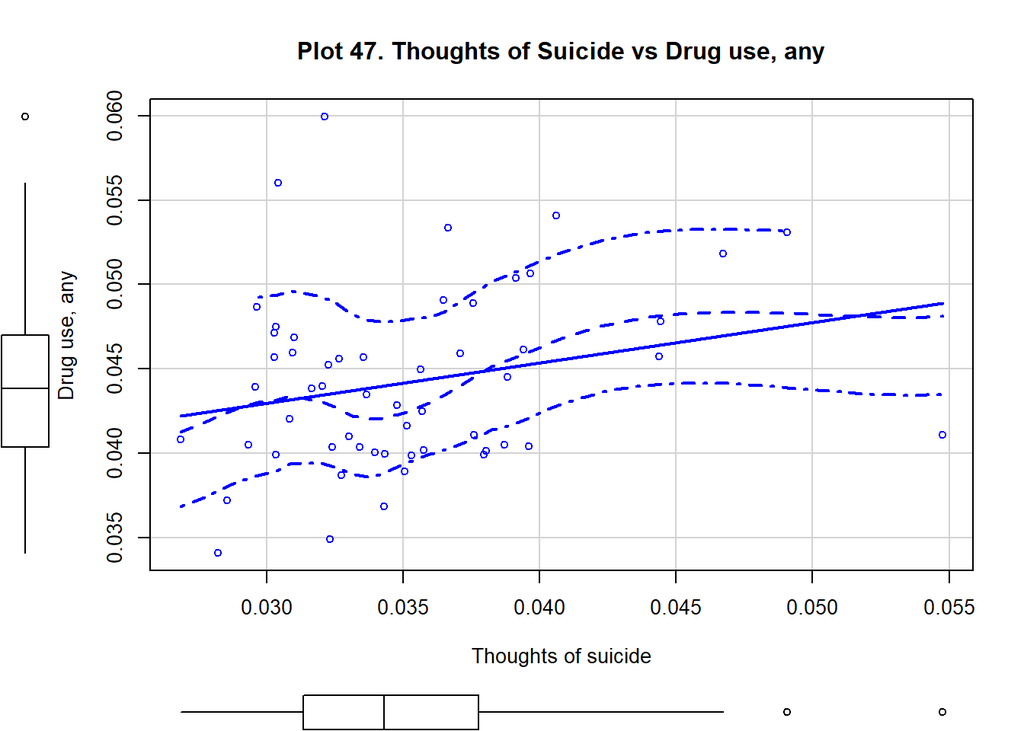

```r
scatterplot(suic_drugu1$Y18P.x~suic_drugu1$Y18P.y,xlab="Thoughts of suicide", ylab="Drug use, any",
   main="Plot 47. Thoughts of Suicide vs Drug use, any")
```

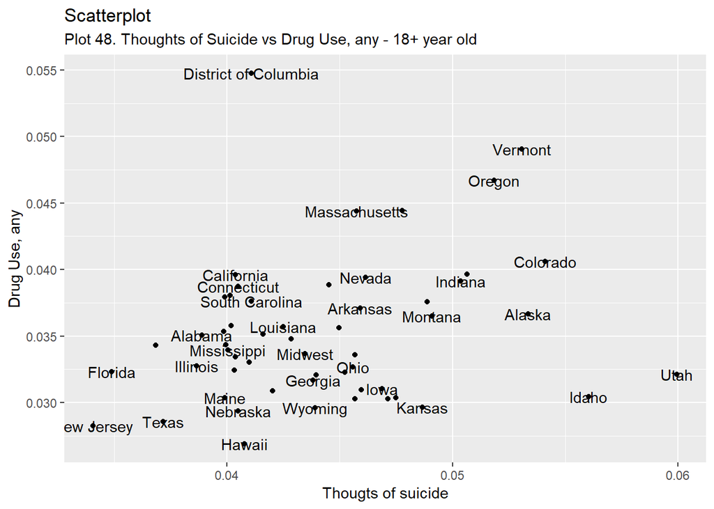

```r
ggplot(suic_drugu1, aes(Y18P.x,Y18P.y)) + geom_point() + geom_text(aes(label=state), check_overlap = TRUE)+
  labs(subtitle="Plot 48. Thoughts of Suicide vs Drug Use, any - 18+ year old", y="Drug Use, any", x="Thougts of suicide", title="Scatterplot")
```

### 6.2.12 Thoughts of suicide vs Drug Use, not Marijuana

The same outliers: DC, Utah, and Idaho. With outliers correlation is 0.31. Without outliers, it goes up to 0.53.

```r
suic_drugu<-merge(suicide_tt1, drug_uset, by = "state")

cor(suic_drugu$Y18P.x, suic_drugu$Y18P.y)
```

```
## [1] 0.3126032
```

```r
cor(suic_drugu$Y18_25.x, suic_drugu$Y18_25.y)
```

```
## [1] 0.2029604
```

```r
suic_drugu_woo<-filter(suic_drugu, !state %in% c('Utah','Idaho', 'District of Columbia'))

cor(suic_drugu_woo$Y18P.x, suic_drugu_woo$Y18P.y)
```

```
## [1] 0.5261027
```

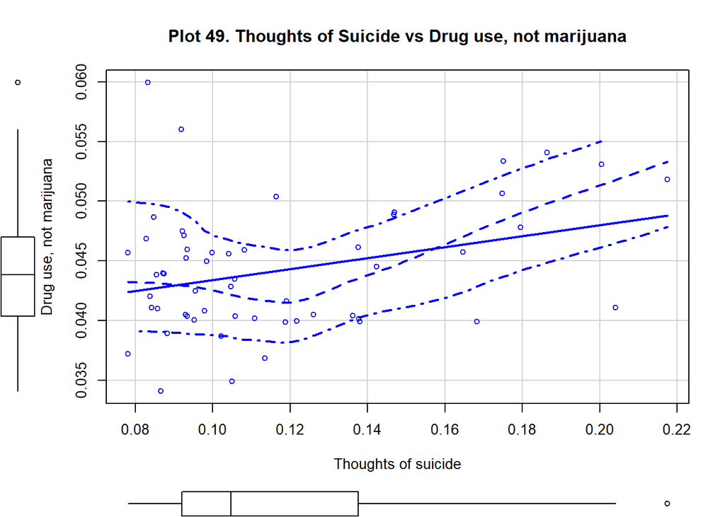

```r
scatterplot(suic_drugu$Y18P.x~suic_drugu$Y18P.y,xlab="Thoughts of suicide", ylab="Drug use, not marijuana",
   main="Plot 49. Thoughts of Suicide vs Drug use, not marijuana")
```

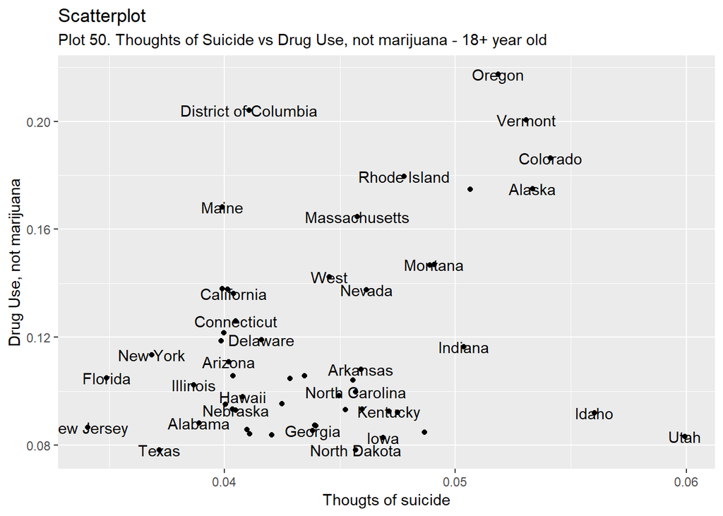

```r
ggplot(suic_drugu, aes(Y18P.x,Y18P.y)) + geom_point() + geom_text(aes(label=state), check_overlap = TRUE)+
  labs(subtitle="Plot 50. Thoughts of Suicide vs Drug Use, not marijuana - 18+ year old", y="Drug Use, not marijuana", x="Thougts of suicide", title="Scatterplot")
```

### 6.2.13 Linear regression - “Thoughts of suicide”.

Now that we gained insight into mental health and substance abuse drivers behind thoughts of suicide, we can try to build basic Linear Regression. Please note that our main goal is not to model thoughts of suicide; however, it might help us to understand better what drives people to thoughts of suicide and what states are effected the worse.

The model calculates rate of suicide thoughts based on serious mental illness, painkillers abuse rates, and use of any drug.

The adjusted R-squired is 0.72. It is not that great.

```r
SAMHA_masterLR<-SAMHA_master

SAMHA_masterLR$Painkillers2<-SAMHA_masterLR$Painkillers**2

SAMHA_masterLR$Painkillers3<-SAMHA_masterLR$Painkillers**3

SAMHA_masterLR$DrugAny2<-SAMHA_masterLR$DrugAny**2

SAMHA_masterLR$DrugAny3<-SAMHA_masterLR$DrugAny**3

model <- lm( ThoughtSuic~ SerMH+Painkillers3+DrugAny+DrugAny2+DrugAny3, data = SAMHA_masterLR)

model
```

```
##
## Call:
## lm(formula = ThoughtSuic ~ SerMH + Painkillers3 + DrugAny + DrugAny2 +
##     DrugAny3, data = SAMHA_masterLR)
##
## Coefficients:
##  (Intercept)         SerMH  Painkillers3       DrugAny      DrugAny2
##    4.900e-02     9.754e-01    -1.639e+04    -1.032e+00     7.421e+00
##     DrugAny3
##   -1.667e+01
```

```r
summary(model)
```

```
##
## Call:
## lm(formula = ThoughtSuic ~ SerMH + Painkillers3 + DrugAny + DrugAny2 +
##     DrugAny3, data = SAMHA_masterLR)
##
## Residuals:
##        Min         1Q     Median         3Q        Max
## -0.0065928 -0.0016519 -0.0000169  0.0021532  0.0059593
##
## Coefficients:
##                Estimate Std. Error t value Pr(>|t|)
## (Intercept)   4.900e-02  2.203e-02   2.224   0.0312 *
## SerMH         9.754e-01  1.231e-01   7.921  4.5e-10 ***
## Painkillers3 -1.639e+04  5.682e+03  -2.884   0.0060 **
## DrugAny      -1.032e+00  4.888e-01  -2.110   0.0404 *
## DrugAny2      7.421e+00  3.567e+00   2.081   0.0432 *
## DrugAny3     -1.667e+01  8.306e+00  -2.007   0.0507 .
## ---
## Signif. codes:  0 '***' 0.001 '**' 0.01 '*' 0.05 '.' 0.1 ' ' 1
##
## Residual standard error: 0.002902 on 45 degrees of freedom
## Multiple R-squared:  0.7441, Adjusted R-squared:  0.7157
## F-statistic: 26.18 on 5 and 45 DF,  p-value: 2.734e-12
```

#### 6.2.13.1 Residual Plot.

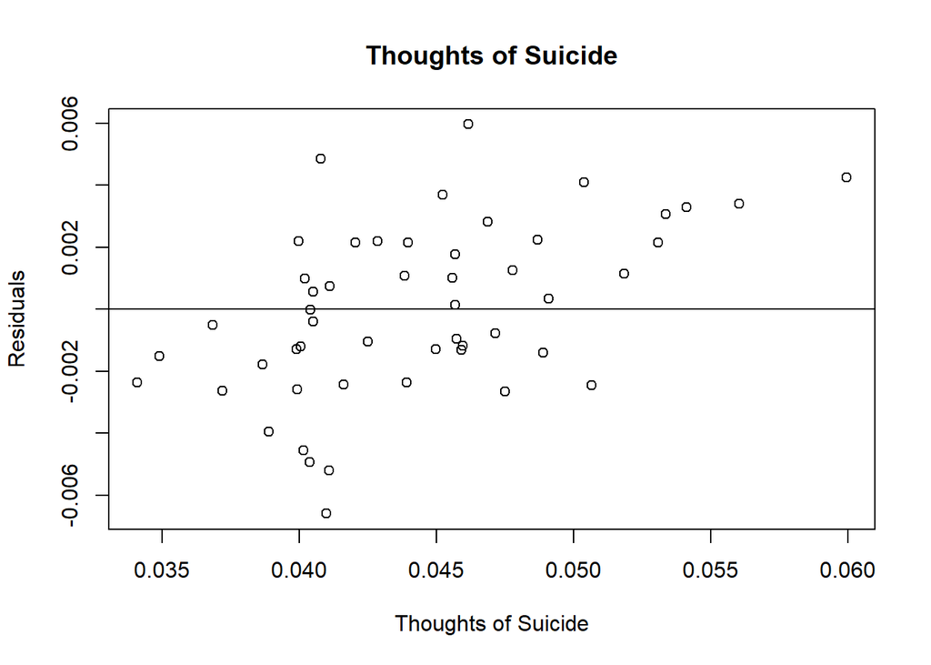

```r
myres = resid(model)

plot(SAMHA_masterLR$ThoughtSuic, myres, ylab="Residuals", xlab="Thoughts of Suicide", main="Thoughts of Suicide")

abline(0, 0)
```

### 6.2.14 SAMHA Survey - Clustering.

I will use 4 clusters, which is perfect for me, so I can kind of imitate 4 regions of USA. Let’s if clusters correspond to 4 regions.

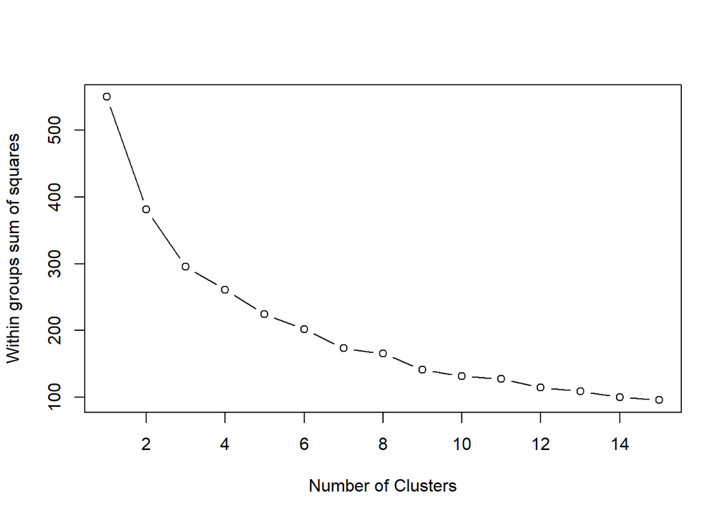

```r
SAMHA_masterC<-SAMHA_master

row.names(SAMHA_masterC)<-SAMHA_masterC[,1]

SAMHA_masterC <- scale(SAMHA_masterC[-1])

wss <- (nrow(SAMHA_masterC)-1)*sum(apply(SAMHA_masterC,2,var))

for (i in 2:15) wss[i] <- sum(kmeans(SAMHA_masterC,
    centers=i)$withinss)
plot(1:15, wss, type="b", xlab="Number of Clusters",
  ylab="Within groups sum of squares")
```

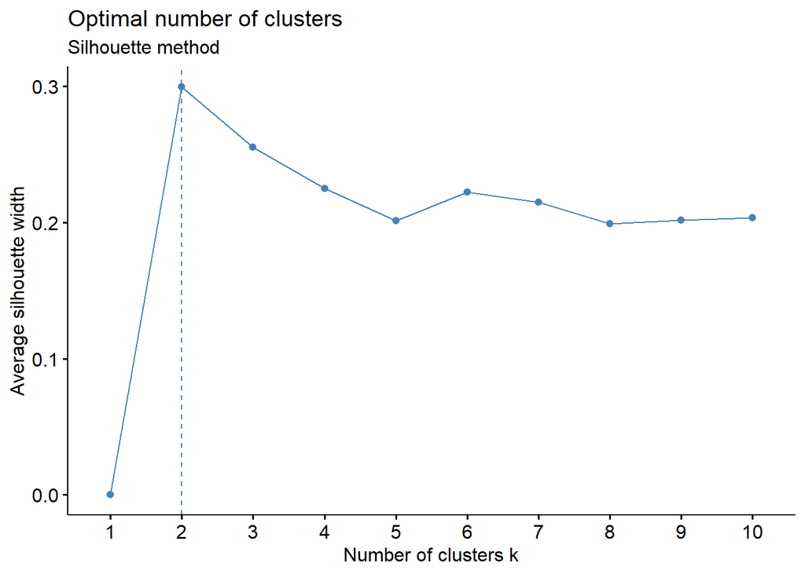

```r
fviz_nbclust(SAMHA_masterC, kmeans, method = "silhouette")+
  labs(subtitle = "Silhouette method")
```

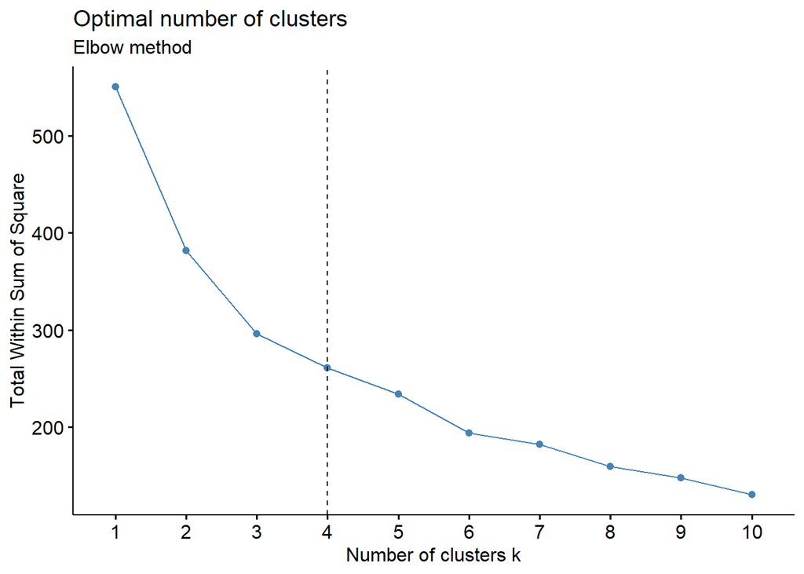

```r
# Elbow method
fviz_nbclust(SAMHA_masterC, kmeans, method = "wss") +
    geom_vline(xintercept = 4, linetype = 2)+
  labs(subtitle = "Elbow method")
```

```r
fit <- kmeans(SAMHA_masterC, 4)

aggregate(SAMHA_masterC,by=list(fit$cluster),FUN=mean)
```

```
##   Group.1 ThoughtSuic       SerMH  Painkillers    DrugNoM    DrugAny
## 1       1   0.6007879  1.08414059  1.158150114 -0.2595276 -0.5611673
## 2       2  -0.2228678 -0.08459446  0.229540261 -0.3202326 -0.3565953
## 3       3  -0.8861016 -1.19118857 -1.211278204 -0.4452622 -0.3620547
## 4       4   0.9523062  0.61667459  0.003339082  1.4147873  1.6737100
##        Binge    DrugDis     AlcDis     AlcUse     Heroin   SubAbuse
## 1 -1.1437122 -0.2697160 -0.9377813 -1.4026162  0.1236364 -0.8403990
## 2  0.3807154 -0.1843569  0.2039108  0.2981129  0.1228629  0.1670663
## 3 -0.2742555 -0.6022033 -0.5160975 -0.0887141 -0.4732574 -0.6271312
## 4  0.8149568  1.3844227  1.2416685  0.9813414  0.2704450  1.3549502
```

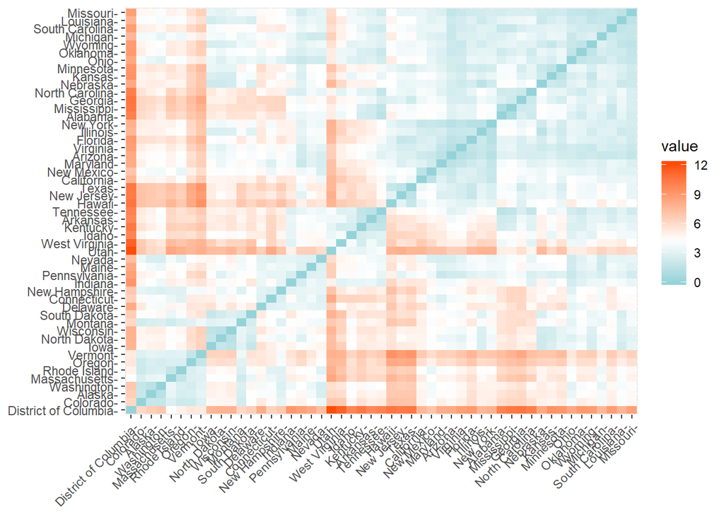

```r
mydata <- data.frame(SAMHA_masterC, fit$cluster)

distance <- get_dist(SAMHA_masterC)

fviz_dist(distance, gradient = list(low = "#00AFBB", mid = "white", high = "#FC4E07"))
```

```r
k2 <- kmeans(SAMHA_masterC, centers = 4, nstart = 25)

str(k2)
```

```
## List of 9
##  $ cluster     : Named int [1:51] 4 1 3 4 3 1 1 1 1 3 ...
##   ..- attr(*, "names")= chr [1:51] "Alabama" "Alaska" "Arizona" "Arkansas" ...
##  $ centers     : num [1:4, 1:11] 0.664 -0.178 -0.886 0.489 0.383 ...
##   ..- attr(*, "dimnames")=List of 2
##   .. ..$ : chr [1:4] "1" "2" "3" "4"
##   .. ..$ : chr [1:11] "ThoughtSuic" "SerMH" "Painkillers" "DrugNoM" ...
##  $ totss       : num 550
##  $ withinss    : num [1:4] 96.6 59.1 46.2 53.4
##  $ tot.withinss: num 255
##  $ betweenss   : num 295
##  $ size        : int [1:4] 13 14 13 11
##  $ iter        : int 4
##  $ ifault      : int 0
##  - attr(*, "class")= chr "kmeans"
```

```r
k2
```

```
## K-means clustering with 4 clusters of sizes 13, 14, 13, 11
##
## Cluster means:
##   ThoughtSuic       SerMH Painkillers    DrugNoM    DrugAny      Binge
## 1   0.6636423  0.38307248  0.01892408  1.1949376  1.3499637  0.6169255
## 2  -0.1779872 -0.06162524  0.26850653 -0.4827015 -0.4555759  0.5522002
## 3  -0.8861016 -1.19118857 -1.21127820 -0.4452622 -0.3620547 -0.2742555
## 4   0.4894356  1.03347842  1.06741020 -0.2716326 -0.5877050 -1.1077739
##      DrugDis     AlcDis     AlcUse     Heroin   SubAbuse
## 1  1.3773553  0.9877644  0.7975831  0.6819409  1.1710608
## 2 -0.5105397  0.2221695  0.4091577 -0.3076858  0.1150226
## 3 -0.6022033 -0.5160975 -0.0887141 -0.4732574 -0.6271312
## 4 -0.2663110 -0.8401857 -1.3585005  0.1449742 -0.7892183
##
## Clustering vector:
##              Alabama               Alaska              Arizona
##                    4                    1                    3
##             Arkansas           California             Colorado
##                    4                    3                    1
##          Connecticut             Delaware District of Columbia
##                    1                    1                    1
##              Florida              Georgia               Hawaii
##                    3                    3                    3
##                Idaho             Illinois              Indiana
##                    4                    3                    4
##                 Iowa               Kansas             Kentucky
##                    2                    2                    4
##            Louisiana                Maine             Maryland
##                    2                    2                    3
##        Massachusetts             Michigan            Minnesota
##                    1                    2                    3
##          Mississippi             Missouri              Montana
##                    4                    2                    1
##             Nebraska               Nevada        New Hampshire
##                    2                    1                    1
##           New Jersey           New Mexico             New York
##                    3                    3                    3
##       North Carolina         North Dakota                 Ohio
##                    4                    2                    2
##             Oklahoma               Oregon         Pennsylvania
##                    4                    1                    2
##         Rhode Island       South Carolina         South Dakota
##                    1                    2                    2
##            Tennessee                Texas                 Utah
##                    4                    3                    4
##              Vermont             Virginia           Washington
##                    1                    3                    1
##        West Virginia            Wisconsin              Wyoming
##                    4                    2                    2
##
## Within cluster sum of squares by cluster:
## [1] 96.55474 59.11845 46.17610 53.43947
##  (between_SS / total_SS =  53.6 %)
##
## Available components:
##
## [1] "cluster"      "centers"      "totss"        "withinss"
## [5] "tot.withinss" "betweenss"    "size"         "iter"
## [9] "ifault"
```

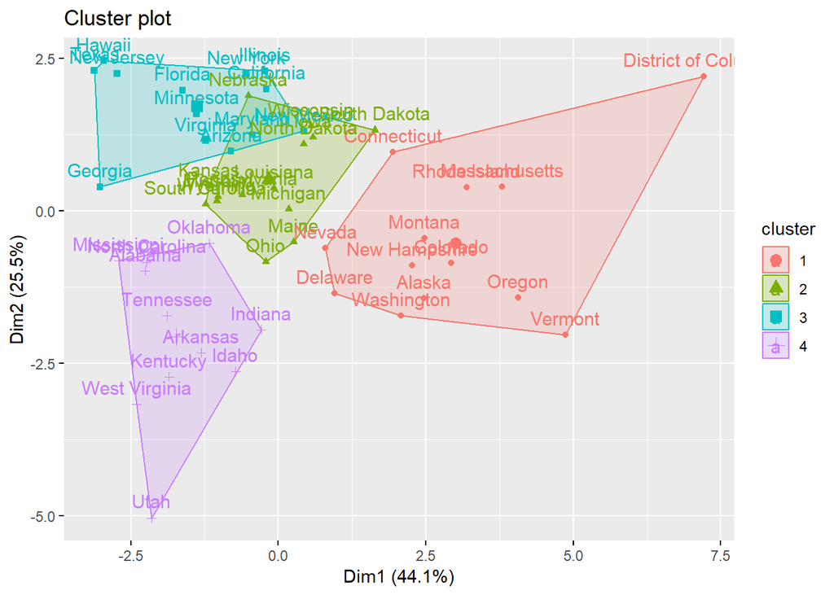

```r
fviz_cluster(k2, data = SAMHA_masterC)
```

So, we have 4 clusters.

As we can see, SAMHA clustering is not very useful indicator of suicide rate. High and low suicide rate states are mixed and not well separated.

## 6.3 DC vs Montana: Suicide Rates

1. Montana has Native American popualtion with a huge suicide rate.
2. DC is Large Central Metro Area, while Montana is a mix of Non Metro and Small Metro, which will account for some discrepency. NonMetro/Small Metro vs Large Metro accounts for 25% difference, but not 4 times we see.

If we compare 2 states by type of suicide based on the method. We can see that majority of suicide comited in Montana is done by using firearms, while non-firearm rates for are pretty close. If we compare White non-fireamr rate is 6.9 vs 8.0 - practically indentical. So, it is very likely that avilability of firearms playing a role in driving suicide rates up(Matthew Miller and Hemenway 2002).

So to summarize, we can say that 3 top drivers for much higher suicide rate in Montana:

1. Hugely high suicide rate among Native American population in Montana
2. Rural, isolated envorement in Montana
3. High gun ownership and corresponding high firearm suicide rate in Montana

```r
state15_17<-select(state15_17,state,Race,Hispanic.Origin,Gender,X2013.Urbanization,Population, AARate)%>%filter(state=='Montana'|state=='District of Columbia')

state15_17%>%
  kable() %>%
  kable_styling()
```

| state | Race | Hispanic.Origin | Gender | X2013.Urbanization | Population | AARate |
| --- | --- | --- | --- | --- | --- | --- |
| District of Columbia | Black or African American | Not Hispanic or Latino | Female | Large Central Metro | 441333 | 2.8460 |
| District of Columbia | Black or African American | Not Hispanic or Latino | Male | Large Central Metro | 349404 | 13.1180 |
| District of Columbia | White | Not Hispanic or Latino | Male | Large Central Metro | 339134 | 15.3460 |
| Montana | White | Not Hispanic or Latino | Female | Small Metro | 411771 | 12.6575 |
| Montana | American Indian or Alaska Native | Not Hispanic or Latino | Male | Small Metro | 14865 | 79.4025 |
| Montana | White | Not Hispanic or Latino | Male | Small Metro | 403880 | 53.5045 |
| Montana | White | Not Hispanic or Latino | Female | Micropolitan (Nonmetro) | 364414 | 16.8390 |
| Montana | White | Not Hispanic or Latino | Male | Micropolitan (Nonmetro) | 369459 | 48.6820 |
| Montana | American Indian or Alaska Native | Not Hispanic or Latino | Female | NonCore (Nonmetro) | 52546 | 27.9455 |
| Montana | White | Not Hispanic or Latino | Female | NonCore (Nonmetro) | 363771 | 12.6020 |
| Montana | American Indian or Alaska Native | Not Hispanic or Latino | Male | NonCore (Nonmetro) | 50796 | 64.3225 |
| Montana | White | Not Hispanic or Latino | Male | NonCore (Nonmetro) | 374454 | 53.3775 |

```r
state17_DC_Mo<-select(state17_DC_Mo,State,Race,ICD.10.113.Cause.List,Age.Adjusted.Rate)

state17_DC_Mo %>%
  kable() %>%
  kable_styling()
```

| State | Race | ICD.10.113.Cause.List | Age.Adjusted.Rate |
| --- | --- | --- | --- |
| District of Columbia | Black or African American | Intentional self-harm (suicide) by other and unspecified means and their sequelae (*U03,X60-X71,X75-X84,Y87.0) | Unreliable |
| District of Columbia | White | Intentional self-harm (suicide) by other and unspecified means and their sequelae (*U03,X60-X71,X75-X84,Y87.0) | 6.9 |
| Montana | American Indian or Alaska Native | Intentional self-harm (suicide) by discharge of firearms (X72-X74) | Unreliable |
| Montana | American Indian or Alaska Native | Intentional self-harm (suicide) by other and unspecified means and their sequelae (*U03,X60-X71,X75-X84,Y87.0) | 27.5 |
| Montana | White | Intentional self-harm (suicide) by discharge of firearms (X72-X74) | 19.6 |
| Montana | White | Intentional self-harm (suicide) by other and unspecified means and their sequelae (*U03,X60-X71,X75-X84,Y87.0) | 8.0 |

# 7 Conclusion

I feel that I have tried, but I have not gotten very far.Let me summarize what I was able to identify:

1. More quality data needs to be collected about suicide. Currently suicide related data is spread and often incomplete. We need more centralized research. I have scanned papers related to statistics of suicide and volume is not all that big. More needs to be done.
2. Suicide is a complex subject. It is multifaceted. It has roots in social, medical, and biological areas. To view it from only one point would not be enough.
3. Looking at how USA states fare against World countries is depressing. If USA states were independent countries, they would take 5 out of 10 top positions. In addition, suicide rates fall across the world, while here in US they grow every year.
4. Contributing factors responsible for a huge variance in suicide levels across the US states are: ethnicity, residential composition (Large Metro vs Rural areas), availability of guns, mental illness rate, alcohol abuse rate, and drug abuse. Alcohol induced deaths correlate from moderately with suicide.
5. Male and female suicide rates by state strongly correlate, so it is possible that drivers behind suicides for both genders are the same. However, male suicide rates have much more variance to them vs females.
6. Prevalence of serious thoughts of suicide moderately correlate with suicide. Serious mental illness has moderate correlation with suicide rate as well. Next step would be to try to figure out why rates of mental illness/thoughts of suicide fluctuate that much from state to state. Painkiller Abuse Disorder Prevalence correlates with suicides. Considering that problems with painkiller abuse continue to spread it might negatively effect suicide rate in future.
7. Attempt to create Linear Model of Serious Thoughts of Suicide was not very successful. R squire was only 0.72. The variables used in a model were Serious Mental Illness, Painkiller Abuse Disorder, and Drug Use, Any Drug. There must be additional variables which need to be discovered.
8. Clustering states based on SAMHSA survey produced some interesting results. It allowed to cluster states into 4 different groups, however these groups would not correspond to state suicide rates well.
9. Comparing high suicide state (Colorado) and low suicide state (Minnesota) indicates alcohol, drugs, and violence as possible culprits.
10. DC vs Montana. 3 drivers - very high suicide rate among Montana Native American population, rural/small metro environment in Montana, and high gun ownership and correspondingly high gun suicide rate in Montana.

# 8 Recommendations

1. Create centralized public database for suicide data.
2. Create methods of improved data collection related to suicide.
3. Try to understand how other countries were able to lower their suicide rates. For example, Japan had a lot of success.
4. Do more research into connection between mental illness, alcohol, drugs, violence, gun ownership, and suicide.
5. To see if success of low suicide states could be applied to high suicide states.
6. To do more research into how people go from thinking to actually commuting suicide.

# References

CDC. 2018. *About Underlying Cause of Death, 1999-2017*. https://wonder.cdc.gov/ucd-icd10.html.

Gerstman, Bud. Unknown. *14: Correlation*. http://www.sjsu.edu/faculty/gerstman/StatPrimer/correlation.pdf.

M.Groysman. 2018. *Data607_FinalProject_DataFIles*. https://github.com/mgroysman/Data607_FinalProject_DataFIles.

Martin, David. 2018. *U.S. Navy Admiral Scott Stearney Found Dead in Apparent Suicide*. https://www.cbsnews.com/news/scott-stearney-us-navy-admiral-found-dead-apparent-suicide-2018-12-01/.

Matthew Miller, Deborah Azrael, and David Hemenway. 2002. *Household Firearm Ownership and Suicide Rates in the United States*. https://www.jstor.org/stable/3703934?seq=1/analyze.

Riess, Jana. 2016. *Study Shows Link Between Teen Suicide and Mormon Populations*. https://religionnews.com/2016/03/12/study-shows-link-teen-suicide-mormon-populations/.

SAMHSA. 2018. *2016-2017 Nsduh State Prevalence Estimates*. https://www.samhsa.gov/data/report/2016-2017-nsduh-state-prevalence-estimates.

Wikipedia. 2018. *List of Countries by Suicide Rate*. https://en.wikipedia.org/wiki/List_of_countries_by_suicide_rate.